# Supervised Learning - Foundations Project: ReCell

## Final Model

```python
olsmodel_final = sm.OLS(y_train, x_train11).fit() # Running the final model
print(olsmodel_final.summary())
```

```
                              OLS Regression Results
=================================================================================
Dep. Variable:     normalized_used_price   R-squared:                       0.833
Model:                               OLS   Adj. R-squared:                  0.832
Method:                    Least Squares   F-statistic:                     1061.
Date:                   Wed, 22 Nov 2023   Prob (F-statistic):               0.00
Time:                           18:20:30   Log-Likelihood:                 78.926
No. Observations:                   2352   AIC:                            -133.9
Df Residuals:                       2340   BIC:                            -64.69
Df Model:                             11
Covariance Type:               nonrobust
==============================================================================================
                                 coef    std err          t      P>|t|      [0.025      0.975]
----------------------------------------------------------------------------------------------
const                        -40.4072      7.706     -5.244      0.000     -55.518     -25.296
screen_size                    0.0235      0.003      7.725      0.000       0.018       0.029
main_camera_mp                 0.0210      0.001     14.869      0.000       0.018       0.024
selfie_camera_mp               0.0169      0.001     12.048      0.000       0.014       0.020
ram                            0.0237      0.005      5.140      0.000       0.015       0.033
battery                    -1.789e-05   7.21e-06     -2.482      0.013    -3.2e-05   -3.75e-06
release_year                   0.0201      0.004      5.284      0.000       0.013       0.028
normalized_new_price           0.3686      0.014     26.888      0.000       0.342       0.395
weight_log                     0.2838      0.031      9.053      0.000       0.222       0.345
4g_yes                         0.0340      0.015      2.247      0.025       0.004       0.064
device_category_Mid_ranger     0.0994      0.020      5.052      0.000       0.061       0.138
device_category_Premium        0.1410      0.043      3.248      0.001       0.056       0.226
==============================================================================
Omnibus:                      178.758   Durbin-Watson:                   2.011
Prob(Omnibus):                  0.000   Jarque-Bera (JB):              475.104
Skew:                          -0.421   Prob(JB):                    6.80e-104
Kurtosis:                       5.035   Cond. No.                     6.19e+06
==============================================================================

Notes:
[1] Standard Errors assume that the covariance matrix of the errors is correctly specified.
[2] The condition number is large, 6.19e+06. This might indicate that there are
strong multicollinearity or other numerical problems.
```

```python
# Let us write the equation of linear regression
Equation = "used_price_log ="
print(Equation, end=" ")
for i in range(len(x_train11.columns)):
    if i == 0:
        print(olsmodel_final.params[i], "+", end=" ")
    elif i != len(x_train11.columns) - 1:
        print(
            olsmodel_final.params[i],
            "* (",
            x_train11.columns[i],
            ")",
            "+",
            end="  ",
        )
    else:
        print(olsmodel_final.params[i], "* (", x_train11.columns[i], ")")
```

[output not shown]

```python
# function to compute adjusted R-squared
def adj_r2_score(predictors, targets, predictions):
    r2 = r2_score(targets, predictions)
    n = predictors.shape[0]
    k = predictors.shape[1]
    return 1 - ((1 - r2) * (n - 1) / (n - k - 1))


# function to compute MAPE
def mape_score(targets, predictions):
    return np.mean(np.abs(targets - predictions) / targets) * 100


# function to compute different metrics to check performance of a regression model
def model_performance_regression(model, predictors, target):
    """
    Function to compute different metrics to check regression model performance

    model: regressor
    predictors: independent variables
    target: dependent variable
    """

    # predicting using the independent variables
    pred = model.predict(predictors)

    r2 = r2_score(target, pred)  # to compute R-squared
    adjr2 = adj_r2_score(predictors, target, pred)  # to compute adjusted R-squared
    rmse = np.sqrt(mean_squared_error(target, pred))  # to compute RMSE
    mae = mean_absolute_error(target, pred)  # to compute MAE
    mape = mape_score(target, pred)  # to compute MAPE

    # creating a dataframe of metrics
    df_perf = pd.DataFrame(
        {
            "RMSE": rmse,
            "MAE": mae,
            "R-squared": r2,
            "Adj. R-squared": adjr2,
            "MAPE": mape,
        },
        index=[0],
    )

    return df_perf
```

```python
# predictions on the test set
pred = olsmodel_final.predict(x_test11)

df_pred_test = pd.DataFrame({"Actual": y_test, "Predicted": pred})
df_pred_test.sample(10, random_state=1)
```

|  | Actual | Predicted |
| --- | --- | --- |
| 1013 | 3.897924 | 4.006246 |
| 298 | 5.412048 | 5.204405 |
| 1680 | 4.314550 | 4.392181 |
| 1396 | 4.362461 | 4.306493 |
| 1717 | 3.781687 | 3.731927 |
| 1820 | 4.151512 | 4.180071 |
| 509 | 4.244917 | 4.184572 |
| 1403 | 4.363481 | 4.147153 |
| 704 | 4.727299 | 4.906502 |
| 3202 | 4.856474 | 5.142464 |

```python
#we can see that,our model has predicted pretty well
```

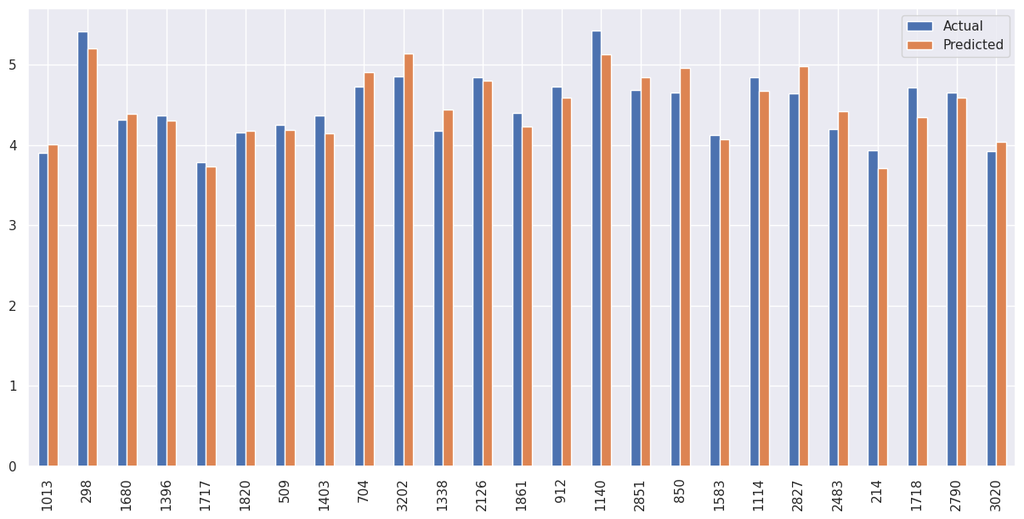

```python
df4 = df_pred_test.sample(25, random_state=1)
df4.plot(kind="bar", figsize=(15, 7))
plt.show()
```

```python
x_train11.columns # checking the columns of final train data
```

```
Index(['const', 'screen_size', 'main_camera_mp', 'selfie_camera_mp', 'ram',
       'battery', 'release_year', 'normalized_new_price', 'weight_log',
       '4g_yes', 'device_category_Mid_ranger', 'device_category_Premium'],
      dtype='object')
```

```python
x_test11.columns # checking the columns of final test data.
```

```
Index(['const', 'screen_size', 'main_camera_mp', 'selfie_camera_mp', 'ram',
       'battery', 'release_year', 'normalized_new_price', 'weight_log',
       '4g_yes', 'device_category_Mid_ranger', 'device_category_Premium'],
      dtype='object')
```

```python
# checking model performance on train set (seen 70% data)
print("Training Performance\n")
olsmodel_final_train_perf = model_performance_regression(olsmodel_final, x_train11, y_train)
olsmodel_final_train_perf
```

```
Training Performance
```

|  | RMSE | MAE | R-squared | Adj. R-squared | MAPE |
| --- | --- | --- | --- | --- | --- |
| 0 | 0.233986 | 0.183402 | 0.832945 | 0.832088 | 4.420821 |

The model performance metrics for the regression model are as follows:

- **Root Mean Squared Error (RMSE):** 0.233986
  - RMSE is a measure of the average magnitude of the errors between predicted and actual values. Lower values indicate better predictive performance.
- **Mean Absolute Error (MAE):** 0.183402
  - MAE represents the average absolute difference between predicted and actual values. It provides a measure of the model's accuracy.
- **R-squared:** 0.832945
  - R-squared indicates the proportion of the variance in the dependent variable explained by the model. A value of 0.832945 suggests that approximately 83.3% of the variability in the dependent variable is accounted for by the model.
- **Adjusted R-squared:** 0.832088
  - Adjusted R-squared adjusts the R-squared value for the number of predictors in the model. It penalizes the addition of unnecessary predictors. The adjusted R-squared is also high, indicating a good fit.
- **Mean Absolute Percentage Error (MAPE):** 4.420821
  - MAPE measures the average percentage difference between predicted and actual values. A lower MAPE indicates better accuracy, with 4.42% on average.

Overall, the model appears to perform well based on these metrics, with low errors and a high proportion of explained variance.

```python
# checking model performance on test set (seen 30% data)
print("Test Performance\n")
olsmodel_final_test_perf = model_performance_regression(olsmodel_final, x_test11, y_test)
olsmodel_final_test_perf
```

```
Test Performance
```

|  | RMSE | MAE | R-squared | Adj. R-squared | MAPE |
| --- | --- | --- | --- | --- | --- |
| 0 | 0.2265 | 0.176543 | 0.854611 | 0.852858 | 4.274903 |

The model performance metrics for the regression model are as follows:

- **Root Mean Squared Error (RMSE):** 0.2265
  - RMSE is a measure of the average magnitude of the errors between predicted and actual values. A lower RMSE indicates better predictive performance.
- **Mean Absolute Error (MAE):** 0.176543
  - MAE represents the average absolute difference between predicted and actual values. It provides a measure of the model's accuracy.
- **R-squared:** 0.854611
  - R-squared indicates the proportion of the variance in the dependent variable explained by the model. A value of 0.854611 suggests that approximately 85.5% of the variability in the dependent variable is accounted for by the model.
- **Adjusted R-squared:** 0.852858
  - Adjusted R-squared adjusts the R-squared value for the number of predictors in the model. It penalizes the addition of unnecessary predictors. The adjusted R-squared is also high, indicating a good fit.
- **Mean Absolute Percentage Error (MAPE):** 4.274903
  - MAPE measures the average percentage difference between predicted and actual values. A lower MAPE indicates better accuracy, with 4.27% on average.

Overall, the model appears to perform well based on these metrics, with low errors and a high proportion of explained variance. The improvement in R-squared and adjusted R-squared values compared to the previous model suggests enhanced explanatory power.

# Comparing linear regression using sklearn and statsmodel

```python
# training performance comparison

models_train_comp_df = pd.concat(
    [linearregression_train_perf.T, olsmodel_final_train_perf.T],
    axis=1,
)

models_train_comp_df.columns = [
    "Linear Regression sklearn",
    "Linear Regression statsmodels",
]

print("Training performance comparison:")
models_train_comp_df
```

```
Training performance comparison:
```

|  | Linear Regression sklearn | Linear Regression statsmodels |
| --- | --- | --- |
| RMSE | 0.226465 | 0.233986 |
| MAE | 0.176350 | 0.183402 |
| R-squared | 0.854656 | 0.832945 |
| Adj. R-squared | 0.852160 | 0.832088 |
| MAPE | 4.273706 | 4.420821 |

both of the training models are close to each other

```python
# training performance comparison

models_train_comp_df = pd.concat(
    [linearregression_test_perf.T, olsmod_final_train_perf.T],
    axis=1,
)

models_train_comp_df.columns = [
    "Linear Regression sklearn",
    "Linear Regression statsmodels",
]

print("Training performance comparison:")
models_train_comp_df
```

[output not shown]

```python
# test performance comparison

models_test_comp_df = pd.concat(
    [linearregression_test_perf.T, olsmodel_final_test_perf.T],
    axis=1,
)

models_test_comp_df.columns = [
    "Linear Regression sklearn",
    "Linear Regression statsmodels",
]

print("Test performance comparison:")
models_test_comp_df
```

```
Test performance comparison:
```

|  | Linear Regression sklearn | Linear Regression statsmodels |
| --- | --- | --- |
| RMSE | 0.226465 | 0.226500 |
| MAE | 0.176350 | 0.176543 |
| R-squared | 0.854656 | 0.854611 |
| Adj. R-squared | 0.852160 | 0.852858 |
| MAPE | 4.273706 | 4.274903 |

The performance of the two models is close to each other

## Actionable Insights and Recommendations

-### Regression Model Insights and Recommendations

#### Model Summary:

The final regression model has an R-squared of 0.833, indicating that approximately 83.3% of the variance in the `normalized_used_price` can be explained by the model. The adjusted R-squared is 0.832, suggesting that the model performs well in explaining the variability in the target variable while accounting for the number of predictors.

#### Significant Predictors:

1. **Screen Size, Main Camera MP, Selfie Camera MP:**
   - As these coefficients are positive and statistically significant, an increase in screen size, main camera megapixels, and selfie camera megapixels is associated with higher normalized used prices.
2. **RAM:**
   - The positive coefficient for RAM suggests that devices with higher RAM tend to have higher normalized used prices.
3. **Release Year:**
   - A positive coefficient indicates that newer models generally have higher normalized used prices.
4. **Normalized New Price:**
   - The positive coefficient suggests that devices with higher normalized new prices have higher normalized used prices.
5. **Weight Log:**
   - Higher weight log is associated with higher normalized used prices, as indicated by the positive coefficient.
6. **4G Support:**
   - Devices with 4G support tend to have higher normalized used prices (positive coefficient).
7. **Device Categories (Mid Ranger, Premium):**
   - Both Mid Ranger and Premium device categories have positive coefficients, indicating higher normalized used prices compared to the budgetcategory.

#### Recommendations:

Based on the model insights, here are actionable recommendations:

1. **Focus on Camera Quality:**
   - Enhance and promote devices with better camera specifications, including higher main and selfie camera megapixels.
2. **Emphasize RAM and Performance:**
   - Highlight devices with higher RAM capacity to attract buyers seeking better performance.
3. **Stay Current with Technology:**
   - Continuously innovate and release newer models, as newer devices tend to have higher normalized used prices.
4. **Price Segmentation:**
   - Consider pricing strategies that align with the normalized new price, ensuring that devices at different price points are positioned appropriately in the market.
5. **Weight Consideration:**
   - If feasible, explore options to optimize device weight, as higher weight is associated with higher normalized used prices.
6. **4G Support and Connectivity:**
   - Promote the presence of 4G support, as it positively influences normalized used prices.
7. **Category-specific Strategies:**
   - Tailor marketing strategies for Mid Ranger and Premium device categories, considering their positive impact on normalized used prices.

#### Caution:

- **Multicollinearity Warning:**
  - The model summary indicates the presence of multicollinearity or other numerical problems. Further investigation into potential collinearity issues among predictors may be necessary.
- **Model Assumptions:**
  - Continue monitoring the model's assumptions, including linearity, independence of errors, and normality of errors.

By incorporating these recommendations and staying vigilant about potential issues, you can optimize product positioning and pricing strategies for higher normalized used prices in the market.